# Curriculum Vitae

Aurora Baluja

14 Xuño, 2021

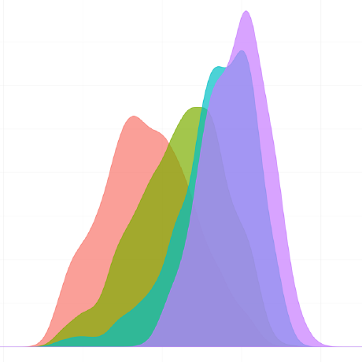

# Datos personales

- Nombre: María Aurora Baluja González.
- Correo-e: mariauror@gmail.com.
- GitHub: [github.com/aurora-mareviv](https://github.com/aurora-mareviv/).
- Blog: www.talesofr.wordpress.com, [aurora-mareviv.github.io](https://aurora-mareviv.github.io/).
- ORCID: 0000-0002-5204-0771.

Descargar CV en PDF

# Formación académica

| Formación | Año |
| --- | --- |
| Licenciatura en Medicina y Cirugía | 1999 - 2005 |
| Diploma de Estudios Avanzados | 2006 - 2007 |
| Doctorado en Medicina - Sobresaliente Cum Laude | 2016 |

# Experiencia

## Profesional

| Puesto | Centro | Año |
| --- | --- | --- |
| Médico Interno Residente | Hospital Clínico Universitario de Santiago | 2006 - 2010 |
| Facultativo Especialista en Anestesiología | Hospital Clínico Universitario de Santiago | 2010 - 2011 |
| Contrato de Formación ‘Del Río Hortega’ | Hospital Clínico Universitario de Santiago | 2011 - 2014 |
| Facultativo Especialista en Anestesiología | Hospital Clínico Universitario de Santiago | 2014 - actualidad |

## Docente

### Docencia desempeñada

| Puesto | Centro | Año |
| --- | --- | --- |
| Colaboradora Docente | Universidade de Santiago de Compostela | 2008 - 2018 |
| Curso: Soporte Vital Avanzado | Hospital Clínico Universitario de Santiago | 2010 - 2011 |
| Curso: Soporte Vital Avanzado | Hospital Clínico Universitario de Santiago | 2015 - 2016 |
| Seminario: Uso de R Markdown e Shiny | Grupo de Medicina Xenómica | 2016 |

# Investigación

## Artículos

#### Publicaciones en revistas

- Taboada M, Baluja A, Santos LD, González I, Veiras S, Caruezo V, Naveira A, Mirón P, Novoa C, Doldán P, Calvo A, Tubio A, Selas S, Eiras M, Martínez A, Campaña O, Rodríguez MT, Diaz-Vieito M, Cariñena A, Otero P, Mariño G, Domínguez M, Muniategui I, Aneiros F, Alvarez J. Effectiveness of dexmedetomidine combined with high flow nasal oxygen and long periods of awake prone positioning in moderate or severe COVID-19 pneumonia. J Clin Anesth. 2021; 72: 110261. [Enlace](http://www.pubmed.gov/33839432)
- Taboada M, Baluja A, Park SH, Otero P, Gude C, Bolón A, Ferreiroa E, Tubio A, Cariñena A, Caruezo V, Alvarez J, Atanassoff PG. Complications during repeated tracheal intubation in the Intensive Care Unit. A prospective, observational study comparing the first intubation and the reintubation. Rev Esp Anestesiol Reanim (Engl Ed). 2021; Epub ahead of print: . [Enlace](http://www.pubmed.gov/33736868)
- Martinez-Sande JL, Garcia-Seara J, Gonzalez-Melchor L, Rodriguez-Mañero M, Baluja A, Fernandez-Lopez XA, Gonzalez Juanatey JR. Conventional single-chamber pacemakers versus transcatheter pacing systems in a “real world” cohort of patients: A comparative prospective single-center study. Indian Pacing Electrophysiol J. 2021; 21: 89-94. [Enlace](http://www.pubmed.gov/33418071)
- López-Canoa JN, Couselo-Seijas M, Baluja A, González-Melchor L, Rozados A, Llorente-Cortés V, de Gonzalo-Calvo D, Guerra JM, Vilades D, Leta R, Martínez-Sande JL, García-Seara FJ, Fernández-López XA, González-Juanatey JR, Eiras S, Rodríguez-Mañero M. Sex-related differences of fatty acid-binding protein 4 and leptin levels in atrial fibrillation. Europace. 2020; 23: 682-690. [Enlace](http://www.pubmed.gov/33319222)
- Rodríguez-Mañero M, Jordá P, Hernandez J, Muñoz C, Grima EZ, García-Fernández A, Cañadas-Godoy MV, Jiménez-Ramos V, Oloriz T, Basterra N, Calvo D, Pérez-Álvarez L, Arias MA, Expósito V, Alemán A, Díaz-Infante E, Guerra-Ramos JM, Fernández-Armenta J, Arce-Leon NA, Sanchez-Gómez JM, Sousa P, García-Bolao I, Baluja A, Campuzano O, Sarquella-Brugada G, Martinez-Sande JL, González-Juanatey JR, Gimeno JR, Brugada J, Arbelo E. Long-term prognosis of women with Brugada syndrome and electrophysiological study. Heart Rhythm. 2020; 18: 664-671. [Enlace](http://www.pubmed.gov/33359877)
- Taboada M, Rama P, Pita-Romero R, Moreno E, Leal S, Varela M, Cid M, Caruezo V, Alvarado de la Torre S, Corujeira M, Sarmiento A, Domínguez B, Diaz P, Cánovas L, López Sánchez M, Vilas E, Rodríguez A, Freire L, Domínguez S, Baluja A, Atanassoff PG. Critically ill COVID-19 patients attended by anesthesiologists in northwestern Spain: a multicenter prospective observational study. Rev Esp Anestesiol Reanim (Engl Ed). 2020; 68: 10-20. [Enlace](http://www.pubmed.gov/33077309)
- Taboada M, Rodríguez N, Riveiro V, Abelleira R, Ricoy J, Lama A, Casal A, Lourido T, Rabade C, Molinos S, Diaz JA, Valdés L, Pose A, Baluja A, Alvarez J. Short-term outcomes of 50 patients with acute respiratory distress by COVID-19 where prone positioning was used outside the ICU. J Clin Anesth. 2020; 67: 110028. [Enlace](http://www.pubmed.gov/32882504)
- Taboada M, González M, González I, García J, Eiras M, Vieito MD, Naveira A, Otero P, Campaña O, Muniategui I, Tubio A, Costa J, Selas S, Cariñena A, Martínez A, Veiras S, Aneiros F, Caruezo V, Baluja A, Alvarez J. Effectiveness of Prone Positioning in Nonintubated Intensive Care Unit Patients With Moderate to Severe Acute Respiratory Distress Syndrome by Coronavirus Disease 2019. Anesth Analg. 2020; 132: 25-30. [Enlace](http://www.pubmed.gov/32947292)
- Baluja A, Arines J, Vilanova R, Cortiñas J, Bao-Varela C, Flores-Arias MT. UV light dosage distribution over irregular respirator surfaces. Methods and implications for safety. J Occup Environ Hyg. 2020; 17: 390-397. [Enlace](http://www.pubmed.gov/32795221)
- Taboada M, Rodríguez N, Riveiro V, Baluja A, Atanassoff PG. Prone positioning in awake non-ICU patients with ARDS caused by COVID-19. Anaesth Crit Care Pain Med. 2020; 39: 581-583. [Enlace](http://www.pubmed.gov/32828956)
- Cordero A, Rodríguez-Mañero M, Bertomeu-González V, García-Acuña JM, Baluja A, Agra-Bermejo R, Cid B, Zuazola P, González-Juanatey JR. New-onset heart failure after acute coronary syndrome in patients without heart failure or left ventricular dysfunction. Rev Esp Cardiol (Engl Ed). 2020; 74: 494-501. [Enlace](http://www.pubmed.gov/32448726)
- Baluja A, Rodríguez-Mañero M, Cordero A, Kreidieh B, Iglesias-Alvarez D, García-Acuña JM, Martínez-Gómez A, Agra-Bermejo R, Alvarez-Rodríguez L, Abou-Jokh C, López-Ratón M, Gude-Sampedro F, Alvarez-Escudero J, González-Juanatey JR. Prediction of major adverse cardiac, cerebrovascular events in patients with diabetes after acute coronary syndrome. Diab Vasc Dis Res. 2019; 17: 1479164119892137. [Enlace](http://www.pubmed.gov/31841030)
- Rodríguez-González R, Pollesello P, Baluja A. Effects of Levosimendan on Inflammation and Oxidative Stress Pathways in a Lipopolysaccharide-Stimulated Human Endothelial Cell Model. Biol Res Nurs. 2019; 21: 466-472. [Enlace](http://www.pubmed.gov/31272201)
- Taboada M, Baluja A, Cariñena A, Caruezo V, Alvarez J. Intubation in Operating Room versus Intensive Care: Reply. Anesthesiology. 2019; 130: 1090-1091. [Enlace](http://www.pubmed.gov/31090621)
- Taboada M, Rey R, Martínez S, Soto-Jove R, Mirón P, Selas S, Eiras M, Martínez A, Rial M, Cariñena A, Rodríguez I, Veiras S, Baluja A, Atanassoff PG. Reintubation in the ICU following cardiac surgery: is it more difficult than first-time intubation in the operating room?: A prospective observational study. Eur J Anaesthesiol. 2019; 37: 25-30. [Enlace](http://www.pubmed.gov/31107352)
- Fernández AL, Baluja A, Al-Hamwy Z, Alvarez J. Postoperative hyperbilirubinemia and Gilbert’s syndrome in patients undergoing cardiac surgery. Ann Card Anaesth. 2019; 22: 207-209. [Enlace](http://www.pubmed.gov/30971605)
- Lopez-Canoa JN, Baluja A, Couselo-Seijas M, Naveira AB, Gonzalez-Melchor L, Rozados A, Martínez-Sande L, García-Seara J, Fernandez-Lopez XA, Fernandez AL, Gonzalez-Juanatey JR, Eiras S, Rodriguez-Mañero M. Plasma FABP4 levels are associated with left atrial fat volume in persistent atrial fibrillation and predict recurrence after catheter ablation. Int J Cardiol. 2019; 292: 131-135. [Enlace](http://www.pubmed.gov/31005413)
- Taboada M, Soto-Jove R, Mirón P, Martínez S, Rey R, Ferreiroa E, Almeida X, Baluja A. Evaluation of the laryngoscopy view using the modified Cormack-Lehane scale during tracheal intubation in an intensive care unit. A prospective observational study. Rev Esp Anestesiol Reanim (Engl Ed). 2019; 66: 250-258. [Enlace](http://www.pubmed.gov/30862397)
- Rodríguez-Mañero M, Kreidieh B, Valderrábano M, Baluja A, Martínez-Sande JL, García-Seara J, Díaz-Fernández B, Pereira-Vázquez M, Lage R, González-Melchor L, Fernández-López XA, González-Juanatey JR. Ablation of atrial fibrillation in patients with Brugada syndrome: A systematic review of the literature. J Arrhythm. 2019; 35: 18-24. [Enlace](http://www.pubmed.gov/30805040)
- Cabadas Avión R, Baluja A, Ojea Cendón M, Leal Ruiloba MS, Vázquez López S, Rey Martínez M, Magdalena López P. Effectiveness and safety of gastrointestinal endoscopy during a specific sedation training program for non-anesthesiologists. Rev Esp Enferm Dig. 2018; 111: 199-208. [Enlace](http://www.pubmed.gov/30507244)
- Rodríguez-Mañero M, Valderrábano M, Baluja A, Kreidieh O, Martínez-Sande JL, García-Seara J, Saenen J, Iglesias-Álvarez D, Bories W, Villamayor-Blanco LM, Pereira-Vázquez M, Lage R, Heidbuchel H, González-Juanatey JR, Sarkozy A. Validating Left Atrial Low Voltage Areas During Atrial Fibrillation and Atrial Flutter Using Multielectrode Automated Electroanatomic Mapping. JACC Clin Electrophysiol. 2018; 4: 1541-1552. [Enlace](http://www.pubmed.gov/30573117)
- Sandorfi G, Rodriguez-Mañero M, Saenen J, Baluja A, Bories W, Huybrechts W, Miljoen H, Vandaele L, Heidbuchel H, Sarkozy A. Less Pulmonary Vein Reconnection at Redo Procedures Following Radiofrequency Point-by-Point Antral Pulmonary Vein Isolation With the Use of Contemporary Catheter Ablation Technologies. JACC Clin Electrophysiol. 2018; 4: 1556-1565. [Enlace](http://www.pubmed.gov/30573119)
- Cabadas Avión R, Leal Ruiloba MS, Vázquez López S, Ojea Cendón M, Wi Hijazi I, Baluja González MA. A descriptive monitoring study of a non-anesthetist sedation quality program. Rev Esp Enferm Dig. 2018; 111: 55-62. [Enlace](http://www.pubmed.gov/30424678)
- Hernandez-Pacheco N, Guillen-Guio B, Acosta-Herrera M, Pino-Yanes M, Corrales A, Ambrós A, Nogales L, Muriel A, González-Higueras E, Diaz-Dominguez FJ, Zavala E, Belda J, Ma SF, Villar J, Flores C, Villar J, Fernández RL, Flores C, Pino-Yanes M, Acosta-Herrera M, Pérez-Méndez L, Corrales A, Espinosa E, Domínguez D, Blanco J, Muriel A, Sagredo V, Ballesteros JC, Ambrós A, Cdel Campo R, Gandía F, Nogales L, Fernández R, Subirá C, Baluja A, Añón JM, González E, Solano R, Carriedo D, Diaz-Dominguez FJ, Adalia R, Zavala E. A vascular endothelial growth factor receptor gene variant is associated with susceptibility to acute respiratory distress syndrome. Intensive Care Med Exp. 2018; 6: 16. [Enlace](http://www.pubmed.gov/29987654)
- Cabadas Avion R, Ojea Cendón M, Leal Ruiloba MS, Baluja González MA, Sobrino Ramallo J. Prospective analysis of the complications, efficacy, and satisfaction level on the sedation performed by anaesthetists in gastrointestinal endoscopy. Rev Esp Anestesiol Reanim (Engl Ed). 2018; 65: 504-513. [Enlace](http://www.pubmed.gov/30055768)
- Veiras S, Rodriguez-Gonzalez R, Sobrino T, Rodriguez J, Baluja A, Alvarez J. Sevoflurane but not Propofol Induces Immunomodulatory Effects in Patients Undergoing Aortic Valve Replacement and Cardiopulmonary Bypass. International Journal of Anesthetics and Anesthesiology. 2018; 5(1): 068. [Enlace](https://doi.org/10.23937/2377-4630/1410068)
- Taboada M, Doldan P, Calvo A, Almeida X, Ferreiroa E, Baluja A, Cariñena A, Otero P, Caruezo V, Naveira A, Otero P, Alvarez J. Comparison of Tracheal Intubation Conditions in Operating Room and Intensive Care Unit: A Prospective, Observational Study. Anesthesiology. 2018; 129: 321-328. [Enlace](http://www.pubmed.gov/29787386)
- Taboada M, Calvo A, Doldán P, Ramas M, Torres D, González M, Rodríguez A, Lombardía M, Fernandez C, Baluja A, Otero P. Are «off hours» intubations a risk factor for complications during intubation? A prospective, observational study. Med Intensiva (Engl Ed). 2017; 42: 527-533. [Enlace](http://www.pubmed.gov/29275003)
- Orduña Valls JM, Vallejo R, López Pais P, Soto E, Torres Rodríguez D, Cedeño DL, Tornero Tornero C, Quintáns Rodríguez M, Baluja González A. Anatomic and Ultrasonographic Evaluation of the Knee Sensory Innervation: A Cadaveric Study to Determine Anatomic Targets in the Treatment of Chronic Knee Pain. Reg Anesth Pain Med. 2016; 42: 90-98. [Enlace](http://www.pubmed.gov/27922951)
- López P, Freijeiro M, Torres D, Baluja A, Vidal I, Alvarez J. Avances en el tratamiento del dolor. Aplicaciones clínicas. Progress in the treatment of pain. Clinical applications. Medicine - Programa de Formación Médica Continuada Acreditado. 2016; 12(23): 1350-1358. [Enlace](http://www.sciencedirect.com/science/article/pii/S0304541216302281)
- Rodríguez-González R, Sobrino T, Veiga S, López P, Rodríguez-García J, del Río SV, Baluja A, Castillo J. Neuroprotective effects of dexmedetomidine conditioning strategies: Evidences from an in vitro model of cerebral ischemia. Life Sci. 2015; 144: 162-9. [Enlace](http://www.pubmed.gov/26655164)
- Alvarez Escudero J, Calvo Vecino JM, Veiras S, García R, González A, Alvarez Escudero J, Calvo Vecino JM, Baluja A, Cabadas R, Cariñena A, Garcia R, González A, González-Juanatey JR, Gilsanz F, Muñoz Aguilera R, Muñoz P, Solera J, Martín Trapero C, Ortega Urbaneja M, Veiras S, Abad Gurumeta A, Acosta F, Alvarez J, Baños G, Calderón E, Castaño B, Casans Francés R, De Paz D, Emad-Assi A, Espinosa AV, García G, García J, García Sánchez JI, Guillén A, Longás Valién J, Matute P, Moguel JA, López Pais P, Olmos MA, Pensado A, Pereira MA, Ripollés Melchor J, Rodríguez Fernández V, Segovia J, Torres LM, Valía JC, Veiga Almeida C, Veintemilla F, Vidal M, Vidal L. Clinical Practice Guideline (CPG). Recommendations on strategy for reducing risk of heart failure patients requiring noncardiac surgery: reducing risk of heart failure patients in noncardiac surgery. Rev Esp Anestesiol Reanim. 2015; 62: 359-419. [Enlace](http://www.pubmed.gov/26164471)
- Acosta-Herrera M, Pino-Yanes M, Blanco J, Ballesteros JC, Ambrós A, Corrales A, Gandía F, Subirá C, Domínguez D, Baluja A, Añón JM, Adalia R, Pérez-Méndez L, Flores C, Villar J. Common variants of NFE2L2 gene predisposes to acute respiratory distress syndrome in patients with severe sepsis. Crit Care. 2015; 19: 256. [Enlace](http://www.pubmed.gov/26077880)
- Rodríguez-González R, Ramos-Nuez NA, Martín-Barrasa JL, López-Aguilar J, Baluja A, Rocco PR, Pelosi P, Villar J. Endotoxin-induced lung alveolar cell injury causes brain cell damage. Exp Biol Med (Maywood). 2014; 240: 135-42. [Enlace](http://www.pubmed.gov/25135986)
- Rodríguez-González R, Martín-Barrasa JL, Ramos-Nuez NA, Cañas-Pedrosa AM, Martínez-Saavedra MT, García-Bello MÁ, López-Aguilar J, Baluja A, Slutsky AS, Villar J. Multiple system organ response induced by hyperoxia in a clinically relevant animal model of sepsis. Shock. 2014; 42: 148-53. [Enlace](http://www.pubmed.gov/24978892)
- Campos F, Sobrino T, Blanco M, López-Arias E, Baluja A, Castillo J. Glutamate neurotoxicity is involved in the neurological damage in patients undergoing extracorporeal circulation. Int J Cardiol. 2014; 172: 481-3. [Enlace](http://www.pubmed.gov/24467976)
- Alvarez J, Baluja A, Selas S, Otero P, Rial M, Veiras S, Caruezo V, Taboada M, Rodriguez I, Castroagudin J, Tome S, Rodriguez A, Rodriguez J. A comparison of dobutamine and levosimendan on hepatic blood flow in patients with a low cardiac output state after cardiac surgery: a randomised controlled study. Anaesth Intensive Care. 2013; 41: 719-27. [Enlace](http://www.pubmed.gov/24180712)
- Rodríguez-González R, Baluja A, Veiras Del Río S, Rodríguez A, Rodríguez J, Taboada M, Brea D. Effects of sevoflurane postconditioning on cell death, inflammation and TLR expression in human endothelial cells exposed to LPS. J Transl Med. 2013; 11: 87. [Enlace](http://www.pubmed.gov/23552565)
- Baluja A, Cariñena A, López P, Tubío A, Acuña I, Pazos L, Rial M, Vidal I, Garea M, Alvarez J. De la infección a la Sepsis. Parte I: Mecanismos de inmunidad y daño tisular. Actualizaciones en Anestesia y Reanimación. 2008; 18: 70-80. [Enlace](http://www.scopus.com/inward/record.url?eid=2-s2.0-53049091283&partnerID=MN8TOARS)
- Alvarez J, Baluja A, Cariñena A, López P, Acuña I, Aguirre P, Amor M, Blanco N, Masid A, Garea M. De la infección a la sepsis. Parte II. Impacto genético. Actualizaciones en Anestesia y Reanimación. 2008; 18: 92-106. [Enlace](http://www.scopus.com/inward/record.url?eid=2-s2.0-84865462403&partnerID=MN8TOARS)
- Aguirre P, Cortiñas J, Pazos L, Amor M, Rial M, Vidal I, Masid A, Blanco N, Baluja A, Alvarez J. Uso de la guía de Eschmann en el manejo de la via aérea. Actualizaciones en Anestesia y Reanimación. 2008; 18: 148-155. [Enlace](http://www.scopus.com/inward/record.url?eid=2-s2.0-59449107464&partnerID=MN8TOARS)

#### Capítulo de libro

- Ginesta V, Pombo MV, Caruezo V, Pazos L, López P, Cariñena A, Baluja A. Traqueotomia percutánea en el paciente neuro-quirúrgico. Pasado y presente de la Neurocirugía. 2009; 79-94. Ed. Publicacións da USC. Santiago de Compostela.

## Congresos Internacionales

#### Ponencias

- Baluja A. Sepsis beyond syndrome: a cohort analysis. Flexible regression through generalized additive models and extensions. GRID[ECMB] Meeting: Applications in Medicine, Biology and Health Care. Santiago de Compostela, Jun 2013.
- J Branco, A Baluja, Elsa Branco, J Singer. O papel do Estatístico nas várias fases do ensaio clínico. III Encontro Luso-Galaico de Biometría. Aveiro, Jul 2018. [Enlace](http://ebio2018-pt.weebly.com/mesa-redonda.html)
- G. Prada (ponente), A. Baluja, P. Vázquez, M. Domínguez, S. Varela, S. Selas, P. Otero, L. Dos-Santos, J. Alvarez. Mortality after on-pump cardiac surgery. 26th annual Congress of the European Society of Critical Care Medicine. Intensive Care Medicine. 2013; 39 (Suppl 2): 0548 (pdf:169). Paris, Oct 2013. [Enlace](http://react-profile.org/Download/ESICM_Abstract_Book_final_version.pdf)
- A. Baluja, G. Prada, M. Rial, I. Vidal, A. Tubío, A. Cariñena, P. López, P. Otero, J. Alvarez. Sepsis after on-pump cardiac surgery. 26th annual Congress of the European Society of Critical Care Medicine. Intensive Care Medicine. 2013; 39 (Suppl 2): 0877 (pdf:259). Paris, Oct 2013. [Enlace](http://react-profile.org/Download/ESICM_Abstract_Book_final_version.pdf)

#### Pósters

- A. Baluja, M. López Ratón, P. Otero Castro, A. Iglesias, J. Alvarez Escudero y C. Cadarso Suárez. Impact of worsening renal function in survival in critical patients. II Encuentro Galaico-Portugues de Biometría. Santiago de Compostela, Jun 2016. [Enlace](http://biometria.sgapeio.es/descargas/Libro_Actas_BIOAPP2016.pdf)
- M. Baluja González, M. Garea Vázquez, P. López Pais, B. Regueiro García, J. Alvarez Escudero. Significance of the presence of bacterial/micotic DNA in procalcitonin levels, in septic surgical patients. Euroanesthesia 2009. Eur J Anaesthesiol. 2009; 26 (Suppl 45): 12AP1-8 (pdf:164). Milan, 2009. [Enlace](http://journals.lww.com/ejanaesthesiology/Citation/2009/06001/EUROANAESTHESIA_2009__The_European_Anaesthesiology.1.aspx)
- M. Baluja González, M. Garea Vázquez, A. Cariñena Amigo, B. Regueiro García, J. Alvarez Escudero. Significance of the presence of bacterial/micotic DNA in TNF-alpha levels, in septic surgical patients. Euroanesthesia 2009. Eur J Anaesthesiol. 2009; 26 (Suppl 45): 12AP1-7 (pdf:164). Milan, 2009. [Enlace](http://journals.lww.com/ejanaesthesiology/Citation/2009/06001/EUROANAESTHESIA_2009__The_European_Anaesthesiology.1.aspx)
- M. Baluja González, M. Garea Vázquez, A. Cariñena Amigo, P. López Pais, J. Alvarez Escudero.. Meaning of previous congestive heart failure in patients with severe sepsis and septic shock. Euroanesthesia 2009. Eur J Anaesthesiol. 2009; 26 (Suppl 45): 12AP1-10 (pdf:165). Milan, 2009. [Enlace](http://journals.lww.com/ejanaesthesiology/Citation/2009/06001/EUROANAESTHESIA_2009__The_European_Anaesthesiology.1.aspx)
- M. Baluja González, M. Garea Vázquez, A. Cariñena Amigo, P. López Pais, J. Alvarez Escudero. Impact on mortality of previous chronic obstructive pulmonary disease in patients with severe sepsis and septic shock. Euroanesthesia 2009. Eur J Anaesthesiol. 2009; 26 (Suppl 45): 12AP1-9 (pdf:165). Milan, 2009. [Enlace](http://journals.lww.com/ejanaesthesiology/Citation/2009/06001/EUROANAESTHESIA_2009__The_European_Anaesthesiology.1.aspx)
- Prada Hervella G., Baluja A., Rodríguez González R., Freijeiro González M., Veiras S., Alvarez J. Effects of desflurane postconditioning on lipopolysaccharide-stimulated human endothelial cells. Euroanesthesia 2015. Eur J Anaesthesiol. 2015; 32 (Suppl 53): 1AP15-6 (pdf:64, book:56). Berlin, 2015. [Enlace](https://www.esahq.org/~/media/ESA/Files/Downloads/Resources-Abstracts-Euroanaesthesia2015/Euroanaesthesia%202015%20Abstract%20Book.ashx)
- Baluja A., Eiras Mariño M., Torres Pérez C.A., Rodríguez González R., Otero P., Alvarez J. Dexmedetomidine conditioning in cerebral ischemia: findings from an in vitro model. Euroanesthesia 2015. Eur J Anaesthesiol. 2015; 32 (Suppl 53): 6AP1-1 (pdf:178, book:170). Berlin, 2015. [Enlace](https://www.esahq.org/~/media/ESA/Files/Downloads/Resources-Abstracts-Euroanaesthesia2015/Euroanaesthesia%202015%20Abstract%20Book.ashx)
- Peiteado M., Baluja A., Ramas M., Dos Santos L., Rodríguez Forja M.J., Alvarez J. Factors related to AKI (acute kidney injury) after HIPEC (hyperthermic intraoperitoneal chemotherapy) with platinum antineoplasic derivatives: case series report. Euroanesthesia 2015. Eur J Anaesthesiol. 2015; 32 (Suppl 53): 8AP10-10 (pdf:291, book:283). Berlin, 2015. [Enlace](https://www.esahq.org/~/media/ESA/Files/Downloads/Resources-Abstracts-Euroanaesthesia2015/Euroanaesthesia%202015%20Abstract%20Book.ashx)
- J. Fernández, S. González, A.G. Tubío, P. López, A. Baluja, I. Vidal, S. Varela, J. Alvarez. Women with low cardiac output after cardiac surgery show a higher risk of death than men. 26th annual Congress of the European Society of Critical Care Medicine. Intensive Care Medicine. 2013; 39 (Suppl 2): 0249 (pdf:83). Paris, 2013. [Enlace](http://react-profile.org/Download/ESICM_Abstract_Book_final_version.pdf)
- J. Fernández, C. Novoa, A. Cariñena, A. Baluja, S. Selas, P. Vázquez, P. Otero, J. Alvarez. Levosimendan increases 28-day survival rate in patients with low cardiac output after cardiac surgery. 26th annual Congress of the European Society of Critical Care Medicine. Intensive Care Medicine. 2013; 39 (Suppl 2): 0720 (pdf:216). Paris, 2013. [Enlace](http://react-profile.org/Download/ESICM_Abstract_Book_final_version.pdf)
- Torres Rodríguez D., Freijeiro González M.C., Orduña Valls J., Baluja González M.A., Calvo Rey A., Alvarez Escudero J. Block superficial cervical plexus to relief chronic neuropatic pain. Euroanesthesia 2016. Eur J Anaesthesiol. 2016; 33 (Suppl 54): 10AP01-1 (pdf:363, book:355). London, 2016. [Enlace](https://www.esahq.org/~/media/ESA/Files/Downloads/Resources-Abstracts-Euroanaesthesia2016/ESA2016_MID.ashx)
- Orduña J., Baluja A., Torres D., López P., Quintáns M., Alvarez J. Anatomical study of sensitive knee innervation in corpses. Therapeutical implications. Euroanesthesia 2016. Eur J Anaesthesiol. 2016; 33 (Suppl 54): 10AP02-9 (pdf:368, book:360). London, 2016. [Enlace](https://www.esahq.org/~/media/ESA/Files/Downloads/Resources-Abstracts-Euroanaesthesia2016/ESA2016_MID.ashx)
- Rodríguez-González R., dos Santos Carregal L., Baluja A. Effects of daptomycin treatment on TNF-alpha-stimulated human endothelial cells. Euroanesthesia 2016. Eur J Anaesthesiol. 2016; 33 (Suppl 54): 11AP02-1 (pdf:382, book:374). London, 2016. [Enlace](https://www.esahq.org/~/media/ESA/Files/Downloads/Resources-Abstracts-Euroanaesthesia2016/ESA2016_MID.ashx)
- Fernández J, Baluja A, Rodríguez-González R, Prada G, Alvarez J. Comparison of APACHE and SOFA scores for survival assessment in sepsis. Euroanesthesia 2016. Eur J Anaesthesiol. 2016; 33 (Suppl 54): . London, 2016. [Enlace](https://www.esahq.org/~/media/ESA/Files/Downloads/Resources-Abstracts-Euroanaesthesia2016/ESA2016_MID.ashx)
- Martinez-Salgado A, Taboada-Muñiz M, Baluja-González A, Lombardía Cortiña M, Otero Castro P, Alvarez-Escudero J. Have reintubation in Intensive Care Unit more technical difficulty and complications in comparison with first intubation? A prospective, observational study. Euroanesthesia 2018. Eur J Anaesthesiol. 2018; 35 (Suppl 56): 09AP01-9. Copenhagen, Jun 2018. [Enlace](https://www.esahq.org/~/media/ESA/Files/Downloads/Ressource-abstract-Euroanaesthes2018/20180914_ESA_Final.ashx)

## Congresos Nacionales

#### Ponencias

- Baluja A (ponente). Neumótorax postraumático en un Servicio de Cirugía Torácica. V Congreso de Cirugía para Estudiantes. Santiago de Compostela, Nov 2002.
- Taboada M (ponente), Bermúdez M, Rodríguez J, Baluja A, Vidal I, Atanassoff PG, Alvarez J. Bloqueo continuo del nervio ciático combinado con PCA. XIV Reunión Anual ESRA España. Sevilla, Oct 2008.
- Baluja A. Investigación básica en dolor. XVII Xornadas da Sociedade Galega de Dor e Coidados Paliativos. Santiago de Compostela, Nov 2012. [Enlace](https://sgador.files.wordpress.com/2012/09/avance_i_dolor12-1.pdf)
- Baluja A (ponente), López-Cacheiro J. Sparklyr: Entorno para Big Data con R. Xornada de Usuarios de R de Galicia. Santiago de Compostela, Oct 2017. [Enlace](https://www.r-users.gal/sites/default/files/libro_actas_xornada_r_2017.pdf)
- Baluja A (ponente), López-Cacheiro J. Iniciación ó Big Data con R coa libraría sparklyr. Xornada de Usuarios de R de Galicia. Santiago de Compostela, Oct 2018. [Enlace](https://www.r-users.gal/sites/default/files/v_xornadasr_baluja.pdf)

#### Pósters

- Baluja A. Funcionalidad del injerto hepático alogénico tras bypass cardiopulmonar: nuestra experiencia. V Congreso para Residentes de la SEDAR. Madrid, Mar 2008.
- Baluja A. Hemofagocitosis y sepsis. V Congreso para Residentes de la SEDAR. Madrid, Mar 2008.
- Cariñena A, Baluja A. Relación entre Indices de riesgo (APACHE II, SOFA) y niveles plasmáticos de Pro-BNP en pacientes sépticos. V Congreso para Residentes de la SEDAR. Madrid, Mar 2008.
- A Baluja, R Rodríguez-González, A Rodríguez. J Rodríguez, M Taboada, J Cortiñas, J Cortés, J Alvarez. Grupo de Investigación traslacional en el Paciente Critico. Presentación de líneas de Investigación. I Xornada de Investigación Biosanitaria. Santiago de Compostela, 2011.
- M. Aurora Baluja, M. Domínguez-Varela, S. Varela-Vales, V. Caruezo, J. Alvarez, B. Regueiro. Identificación microbiológica en el postoperatorio inmediato de pacientes sometidos a CEC. El impacto de Candida spp. 30 Congreso de la SEDAR. Salamanca, May 2011.
- R. Rodríguez-González, A. Baluja, S. Veiras, A. Rodríguez. J. Rodríguez, J. Alvarez. El postcondicionamiento con sevoflurano disminuye la expresión de TLR2 y TLR4 en células endoteliales humanas expuestas a lipopolisacárido. II Xornada de Investigación Biosanitaria. Santiago de Compostela, Abr 2012. [Enlace](http://comunidad.iebschool.com/coinnovacionsanitaria/files/2012/04/ProgramaResumen.IIJornadaInvestigacionBiosanitariaIDIS2012.pdf)
- A. Baluja, M. López, J. Alvarez, A. Carracedo, C. Cadarso. Análisis de Factores Clínicos y Genéticos de Mortalidad en Sepsis. Congreso BioStatNet-Red Nacional de Bioestadística. Santiago de Compostela, Ene 2013. [Enlace](http://eio.usc.es/pub/biostatnet/images/stories/fruit/programa2.pdf)
- L. Dos Santos Carregal, L. Vidal Castro, A. Baluja González, GM. Prada Hervella, A. Cariñena Amigo, J. Alvarez Escudero. Balón de contrapulsación y mortalidad en cirugía cardiaca. 31 Congreso de la SEDAR. Málaga, Mar 2013.
- C. Novoa, J. Fernández, G. Prada, A. Baluja, J. Alvarez. Uso de Levosimendan o catecolaminas en pacientes sometidos a cirugía cardiaca y su influencia en la mortalidad. 31 Congreso de la SEDAR. Málaga, Mar 2013.
- L. Vidal, L. Dos Santos, A. Baluja, G. Prada, A. Cariñena, J. Alvarez. Estudio de la mortalidad ligada a sepsis en una Unidad de Reanimación. 31 Congreso de la SEDAR. Málaga, Mar 2013.
- L. Dos Santos, L. Vidal, A. Baluja, G. Prada, P. López-Pais, J. Alvarez. Importancia de la sepsis en pacientes inmunodeprimidos. 31 Congreso de la SEDAR. Málaga, Mar 2013.
- G. Mariño, C. Novoa, J. Fernández, A. Baluja, R. Rodríguez-González, J. Alvarez. Efectos del postcondicionamiento con sevoflurano en la muerte célular, inflamación y expresión de TLR en células endoteliales humanas expuestas a LPS. 31 Congreso de la SEDAR. Málaga, Mar 2013.
- L. Vidal Castro, L. Dos Santos Carregal, A. Baluja González, G. Prada Hervella, P. López Pais, J. Alvarez Escudero. Swan-Ganz y mortalidad en cirugía cardiaca. 31 Congreso de la SEDAR. Málaga, Mar 2013.
- Baluja A, Vega-Gliemmo A, Fachal L, Alvarez-Iglesias V, López-Ratón M, Cadarso-Suárez C, Rodríguez-González R, Carracedo A, Alvarez J, Salas-Ellacuriaga A. Análisis de factores clínicos y genéticos de mortalidad en sepsis. I Xornada Biointegrasaúde. Santiago de Compostela, Abr 2013.
- Aurora Baluja, Mónica López-Ratón, Carmen Cadarso-Suárez, Angel Carracedo, Julian Alvarez. Long-term survival after sepsis: a cohort 2005-2010. XIV Conferencia Española de Biometría. Ciudad Real, May 2013. [Enlace](http://areaestadistica.uclm.es/biometria2013/ResumenesXIVCEB.pdf)
- Souaf-Khalafi S, Fernández-González A, Baluja A, Sierra-Quiroga J, Adrio-Nazar B, García-Carro J, Martínez-Cereijo JM, Durán Muñoz D. Reemplazo Valvular Aórtico Con Bioprótesis Sin Sutura Perceval: Experiencia Única En Nuestro Centro. Aortic Valve Replacement With Perceval Sutureless Bioprosthesis: Single-Center Experience. *Premio al Mejor Póster*. XXIV Congreso de la Sociedad Española de Cirugía Torácica-Cardiovascular. Murcia, May-Jun 2018. [Enlace](http://congreso2018.sectcv.es)
- Martín-Barrasa JL, Rodríguez-González R, Ramos-Nuez A, Canas-Pedrosa A, Martínez-Saavedra MT, García-Bello MA, López-Aguilar J, Baluja A, Alvarez J, Slutsky A, Villar J. Multiple system organ changes produced by different oxygen concentrations during spontaneus breathing in septic patient: Experimental rat model. I Iberian Congress for Laboratory Animal Science (XIII Congreso SECAL - III Congreso SPCAL). Laboratory Animals. 2015; 49 (S3): 43-44. , 2015.

## Proyectos

#### No competitivos

- Ensayo PI11-0143 - Estudio comparativo, aleatorio, controlado, para valorar la eficacia de la administración de dexametasona en el tratamiento de pacientes con el Síndrome de Distrés Respiratorio Agudo. Inv. Principal: Julián Alvarez Escudero. Promotor: Jesus Villar Hernandez. Duración: 2013 - 2021. [Enlace](https://www.clinicaltrialsregister.eu/ctr-search/search?query=2012-000775-17)
- Intubación en Cuidados Intensivos. ¿Es más difícil la laringoscopia realizada en la Unidad de Cuidados Intensivos en comparación con la de quirófano? Estudio prospectivo y observacional. Inv. Principal: Manuel Taboada Muñiz. Promotor: Pablo Otero Castro. Duración: 2015 - 2018.
- Complicaciones graves tras intubación en Cuidados Críticos. Estudio prospectivo y observacional. Inv. Principal: Manuel Taboada Muñiz. Promotor: Pablo Otero Castro. Duración: 2015 - 2018.
- Farmacogenética de la dopamina; Diferencias individuales de reacción a la dopamina, y búsqueda de predictores de respuesta. Inv. Principal: Angel Carracedo Alvarez. Promotor: Angel Carracedo Alvarez. Duración: 2006 - 2007.

#### Competitivos

- Ensayo RFCLAI004 - Estudio de cohortes prospectivo, aleatorizado, para valorar la eficacia de dos técnicas contra el dolor crónico de rodilla: radiofrecuencia ecoguiada sobre la inervación sensitiva de la rodilla, en comparación con la infiltración intra-articular de corticoides y anestésicos locales guiada por radiografía convencional. Inv. Principal: Jaime Rodríguez García. Promotor: Pablo López Pais. Duración: 2016 - 2019. [Enlace](https://www.clinicaltrialsregister.eu/ctr-search/search?query=2015-002563-41)

## Software

#### Estadístico

- Paquete de [R](https://www.r-project.org/) [`mthapower`](https://CRAN.R-project.org/package=mthapower): para calcular el tamaño de muestra necesario para estudios de asociación genética con ADN mitocondrial. Asimismo puede calcular la potencia estadística *post hoc* de un estudio.  
  Código está basado en el artículo de Samuels et al, [AJHG 2006](https://www.ncbi.nlm.nih.gov/pmc/articles/PMC1424681/).
  - Código fuente publicado en un [repositorio](https://github.com/aurora-mareviv/mthapower) GitHub.
  - Aplicación web escrita en Shiny: aurora.shinyapps.io/mtDNA_power_calc.
- Creación de aplicación web para el cálculo de tamaño muestral y potencia en tests [Chi-cuadrado](https://aurora.shinyapps.io/Chi-square_power_calc/).
- Creación de aplicación web para cálculo de tamaño muestral con el método de [Montecarlo](https://aurora.shinyapps.io/stat_calc/).
- Creación de aplicación web para aleatorizar pacientes en [ensayos](https://aurora.shinyapps.io/random_gen/) clínicos ciegos.
- Aplicación web para planificación de las [visitas de ensayo](https://talesofr.shinyapps.io/trial_calc/) clínico.
- Tutorial para el paquete `sparklyr`, un entorno de R para Big Data: [sparklyr_test](https://aurora-mareviv.github.io/sparklyr_test/#/).

#### Anestesiología y Reanimación

- Calculadoras en Anestesiología: [anescalc](https://anescalc.github.io/).

# Impacto de la investigación

## Índice H

- Índice H (Google Scholar): 11.

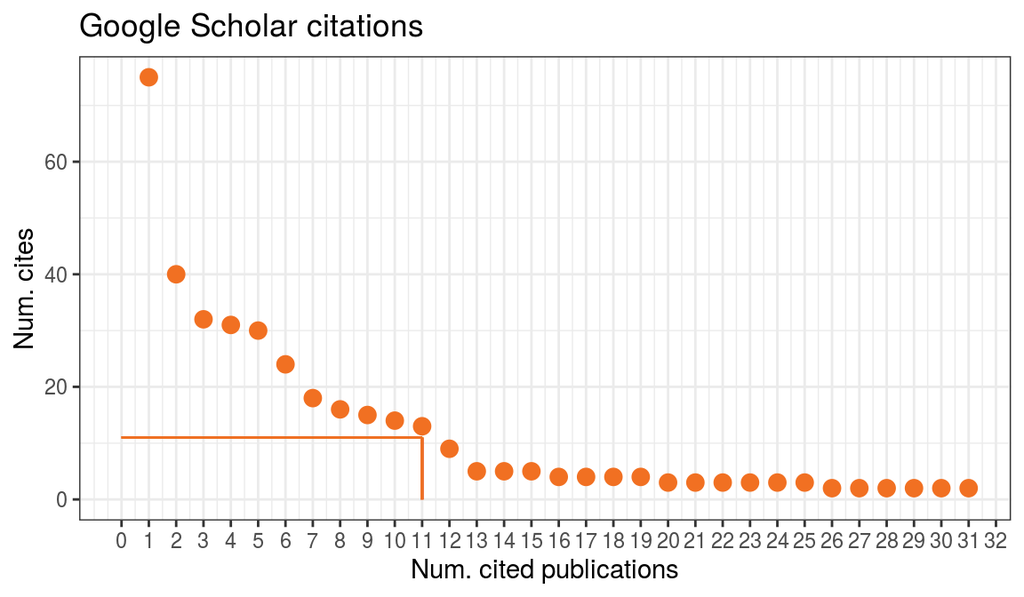

- Cociente m (Indice H / 8 años): 1.38.

## Factor de Impacto

#### Factor de Impacto Acumulado

- FI (SJR) (2017): 26.58.

## Palabras clave

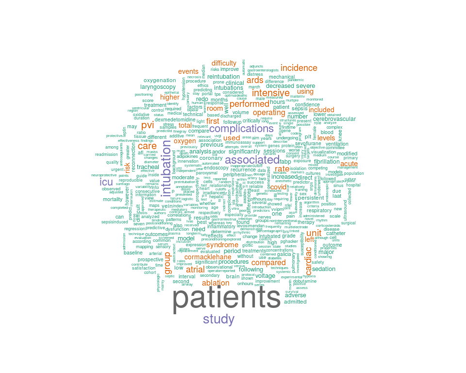

# Otras actividades

- Miembro de la Sociedad Española de Anestesiología y Reanimación [SEDAR](https://www.sedar.es/).
- Miembro de la Asociación Gallega de Anestesia, Reanimación y Dolor [AGARYD](https://agaryd.es).
- Associate Member of the European Society of Anaesthesiology [ESA](http://www.esahq.org/).
- Editora Adjunta de la Revista Española de Anestesiología y Reanimación [REDAR](http://www.elsevier.es/es-revista-revista-espanola-anestesiologia-reanimacion-344) (marzo 2019).
- Miembro de la Sociedade Galega para a Promoción da Estatística e da Investigación de Operacións [SGAPEIO](http://www.sgapeio.es/).
- Miembro de la Red Nacional de Bioestadística [Biostatnet](http://eio.usc.es/pub/biostatnet).
- Diseño y confección de la página web del Servicio de [Anestesioloxía e Reanimación](http://xxisantiago.sergas.es/Paxinas/web.aspx?tipo=paxtab&idLista=3&idContido=283&migtab=56%3b365%3b283) de la Xerencia de Xestión Integrada de Santiago.
- Colaboración en el diseño de la página web de la Sociedad Española de Anestesiología ([SEDAR](https://www.sedar.es/)).
- Lenguajes de programación:
  - Nivel medio: R, SQL, HTML, CSS.
  - Nivel básico/inicial: Python, Bash, PHP, Git, Javascript.
- Estadística:
  - Minería de datos, análisis multivariante, [simulaciones](https://aurora.shinyapps.io/stat_calc/).
  - Uso básico de las infraestructuras de HPC del [CESGA](http://www.cesga.es/).
  - Currículum Vitae programado con R/Rmarkdown.